# Example GCREW Pipeline

Selina Cheng

2022-10-12

# Getting set up

To start out, the user needs to define all of the directories.

1. The source directory, GCREW_LOGGERNET_DATA in Dropbox
2. The intermediary directory, where all intermediate files are stored
3. The output directory, where usable data is made available for researchers as monthly and yearly bundles

```r
source_dir <- paste0("C:/Users/", Sys.getenv("USERNAME"),"/OneDrive - Smithsonian Institution/Documents/GCREW_LOGGERNET_DATA-test")

mid_path <- paste0("C:/Users/", Sys.getenv("USERNAME"),"/OneDrive - Smithsonian Institution/Documents/SMARTX_processing_test")

out_path <- paste0("C:/Users/", Sys.getenv("USERNAME"),"/OneDrive - Smithsonian Institution/Documents/GCREW_RESEARCHER_DATA-test")
```

# Importing files

`dir_names()` creates a list of directories to create, while `create_dirs()` creates the directories if they don’t exist yet.

`file_import()` imports raw files from GCREW_LOGGERNET_DATA that haven’t been processed yet.

## Function execution

```r
my_dirs <- dir_names(mid_path)
```

```
## [1] "Directory names created as follows: "
## $raw
## [1] "C:/Users/ChengS1/OneDrive - Smithsonian Institution/Documents/SMARTX_processing_test/0_raw"
##
## $raw_work
## [1] "C:/Users/ChengS1/OneDrive - Smithsonian Institution/Documents/SMARTX_processing_test/0_raw/raw_working"
##
## $raw_archive
## [1] "C:/Users/ChengS1/OneDrive - Smithsonian Institution/Documents/SMARTX_processing_test/0_raw/raw_archive"
##
## $processed
## [1] "C:/Users/ChengS1/OneDrive - Smithsonian Institution/Documents/SMARTX_processing_test/1_processed"
##
## $proc_work
## [1] "C:/Users/ChengS1/OneDrive - Smithsonian Institution/Documents/SMARTX_processing_test/1_processed/processed_working"
##
## $proc_archive
## [1] "C:/Users/ChengS1/OneDrive - Smithsonian Institution/Documents/SMARTX_processing_test/1_processed/processed_archive"
##
## $sorted
## [1] "C:/Users/ChengS1/OneDrive - Smithsonian Institution/Documents/SMARTX_processing_test/2_sorted"
##
## $sort_work
## [1] "C:/Users/ChengS1/OneDrive - Smithsonian Institution/Documents/SMARTX_processing_test/2_sorted/sorted_working"
##
## $sort_archive
## [1] "C:/Users/ChengS1/OneDrive - Smithsonian Institution/Documents/SMARTX_processing_test/2_sorted/sorted_archive"
##
## $normal
## [1] "C:/Users/ChengS1/OneDrive - Smithsonian Institution/Documents/SMARTX_processing_test/3_normal"
##
## $normal_work
## [1] "C:/Users/ChengS1/OneDrive - Smithsonian Institution/Documents/SMARTX_processing_test/3_normal/normal_working"
##
## $normal_archive
## [1] "C:/Users/ChengS1/OneDrive - Smithsonian Institution/Documents/SMARTX_processing_test/3_normal/normal_archive"
##
## $monthly
## [1] "C:/Users/ChengS1/OneDrive - Smithsonian Institution/Documents/SMARTX_processing_test/4_monthly_working"
```

```r
create_dirs(my_dirs)
```

```
## [1] "0 directories have been created."
```

```r
file_import(source_dir, my_dirs$raw)
```

```
## [1] "1 files have been imported."
```

## Function code

```r
# Create directories
create_dirs <- function(my_dirs){
  out <- 0
  for(n in 1:length(my_dirs)){
    if(!dir.exists(file.path(my_dirs[n]))){
      dir.create(file.path(my_dirs[n]))
      out <- out + 1
    }
  }
  print(paste(out, "directories have been created."))
}

# Import files
file_import <- function (source_dir, raw_dir){
  raw_working <- paste0(raw_dir, "/raw_working")
  raw_archive <- paste0(raw_dir, "/raw_archive")
  # List all files from the source directory folder, does NOT recurse into other folders in directory
  files <- list.files(source_dir, pattern = NULL, all.files = FALSE,
                  full.names = TRUE, recursive = FALSE,
                  ignore.case = FALSE)

  # Remove any file paths that are just folders in the directory
  files <- files[!file.info(files)$isdir]

  # Remove files that are not .dat or .backup extensions
  files <- files[file_ext(files) == "dat" | file_ext(files) == "backup"]

  # Create empty vector for the for loop
  keep_files <- vector(mode = "character", length = length(files))

  # Read in data tables so that we can remove any empty data tables
  for (n in 1:length(files)) {
    dat <- read.table(files[n], sep = ",", quote = "\"'", dec = ".", na.strings = "NA",
                      colClasses = "character", nrows = 6, skip = 0, check.names = FALSE, fill=TRUE,
                      strip.white = FALSE, blank.lines.skip = TRUE)

    # Extract table type from data
    type <- dat[1,1]

    # Depending on type of table, remove tables less than a given length
    if(nrow(dat) > 2 & type == "TOACI1"){
      keep_files[n] <- files[n]
    }
    if(nrow(dat) > 4 & type == "TOA5"){
      keep_files[n] <- files[n]
    }
  }

  keep_files <- keep_files[keep_files != ""]

  # Compare list of incoming files with files from raw_archive
  keep_files_short <- strsplit(keep_files, "/")
  keep_files_short <- sapply(keep_files_short, "[[", length(keep_files_short[[1]]))

  # Read in data from raw_archive
  done_files <- list.files(raw_archive, pattern = NULL, all.files = FALSE,
                           full.names = FALSE, recursive = FALSE,
                           ignore.case = FALSE)

  keep_files <- keep_files[keep_files_short %in% done_files == F]

  # Copy all files to raw_working
  file.copy(keep_files, raw_working)
  print(paste0(length(keep_files), " files have been imported."))
}
```

## Raw file

```r
  # Create list of file names in the raw directory
  files <- list.files(paste0(my_dirs$raw, "/raw_working"), pattern = NULL, all.files = FALSE,
                full.names = TRUE, recursive = TRUE,
                ignore.case = FALSE)

  dat <- readLines(files[1])

  kable(head(dat)) %>% scroll_box(width = "100%")
```

| x |
| --- |
| "TOA5","C3LOG","CR1000","75701","CR1000.Std.28.02","CPU:GCREW_v2.30.cr1","64187","Export" |
| "TIMESTAMP","RECORD","STATNAME","TRef_Avg(1)","TRef_Avg(2)","TRef_Avg(3)","Temp_T_Avg(1)","Temp_T_Avg(2)","Temp_T_Avg(3)","Temp_T_Avg(4)","Temp_T_Avg(5)","Temp_T_Avg(6)","Temp_T_Avg(7)","Temp_T_Avg(8)… |
| "TS","RN","","","","","","","","","","","","","","","","","","","","","","","","","","","","","","","","","","","","","","","","","","","","","","","","","","","","","","","","","","","","","","","","… |
| "","","Smp","Avg","Avg","Avg","Avg","Avg","Avg","Avg","Avg","Avg","Avg","Avg","Avg","Avg","Avg","Avg","Avg","Avg","Avg","Avg","Avg","Avg","Avg","Avg","Avg","Avg","Avg","Avg","Avg","Avg","Avg","Avg","A… |
| "2021-03-24 02:00:00",61683,"C3LOG",11.56,11.52,11.5,10.82,5.636,5.402,7.167,12.49,7.261,"NAN",9.11,14.33,9.09,8.53,11.77,15.84,10.74,9.51,13.3,10.75,5.377,5.424,7.107,12.17,7.317,6.787,9.18,"NAN",13.… |
| "2021-03-24 02:15:00",61684,"C3LOG",11.52,11.49,11.45,10.67,5.65,5.412,7.168,11.72,7.271,"NAN",9.11,12.59,9.1,8.54,11.77,14.32,10.75,9.51,13.3,10.65,5.387,5.434,7.107,11.87,7.326,6.798,9.18,"NAN",13.2… |

# Process raw files

`process()` reads a list of raw .dat files and saves them to .csv format.

## Function execution

```r
process(my_dirs$raw, my_dirs$processed)
```

```
## [1] "Files have been processed."
```

| TIMESTAMP | RECORD | STATNAME | TRef_Avg.1. | TRef_Avg.2. | TRef_Avg.3. | Temp_T_Avg.1. | Temp_T_Avg.2. | Temp_T_Avg.3. | Temp_T_Avg.4. | Temp_T_Avg.5. | Temp_T_Avg.6. | Temp_T_Avg.7. | Temp_T_Avg.8. | Temp_T_Avg.9. | Temp_T_Avg.10. | Temp_T_Avg.11. | Temp_T_Avg.12. | Temp_T_Avg.13. | Temp_T_Avg.14. | Temp_T_Avg.15. | Temp_T_Avg.16. | Temp_T_Avg.17. | Temp_T_Avg.18. | Temp_T_Avg.19. | Temp_T_Avg.20. | Temp_T_Avg.21. | Temp_T_Avg.22. | Temp_T_Avg.23. | Temp_T_Avg.24. | … |
| --- | --- | --- | --- | --- | --- | --- | --- | --- | --- | --- | --- | --- | --- | --- | --- | --- | --- | --- | --- | --- | --- | --- | --- | --- | --- | --- | --- | --- | --- | --- |
| 2021-03-24 02:00:00 | 61683 | C3LOG | 11.56 | 11.52 | 11.50 | 10.82 | 5.636 | 5.402 | 7.167 | 12.49 | 7.261 | NAN | 9.11 | 14.33 | 9.09 | 8.53 | 11.77 | 15.84 | 10.74 | 9.51 | 13.30 | 10.75 | 5.377 | 5.424 | 7.107 | 12.17 | 7.317 | 6.787 | 9.18 | … |
| 2021-03-24 02:15:00 | 61684 | C3LOG | 11.52 | 11.49 | 11.45 | 10.67 | 5.650 | 5.412 | 7.168 | 11.72 | 7.271 | NAN | 9.11 | 12.59 | 9.10 | 8.54 | 11.77 | 14.32 | 10.75 | 9.51 | 13.30 | 10.65 | 5.387 | 5.434 | 7.107 | 11.87 | 7.326 | 6.798 | 9.18 | … |
| 2021-03-24 02:30:00 | 61685 | C3LOG | 11.47 | 11.43 | 11.38 | 10.74 | 5.657 | 5.416 | 7.167 | 12.31 | 7.279 | NAN | 9.11 | 14.38 | 9.11 | 8.55 | 11.77 | 15.61 | 10.75 | 9.52 | 13.30 | 10.70 | 5.396 | 5.441 | 7.109 | 12.64 | 7.329 | 6.804 | 9.18 | … |
| 2021-03-24 02:45:00 | 61686 | C3LOG | 11.43 | 11.38 | 11.34 | 10.83 | 5.664 | 5.419 | 7.166 | 12.39 | 7.289 | NAN | 9.11 | 13.64 | 9.12 | 8.55 | 11.77 | 15.70 | 10.75 | 9.53 | 13.29 | 10.76 | 5.404 | 5.449 | 7.107 | 12.10 | 7.333 | 6.811 | 9.18 | … |
| 2021-03-24 03:00:00 | 61687 | C3LOG | 11.41 | 11.36 | 11.32 | 10.95 | 5.672 | 5.425 | 7.168 | 12.90 | 7.299 | NAN | 9.11 | 14.56 | 9.12 | 8.56 | 11.77 | 16.03 | 10.75 | 9.54 | 13.30 | 10.87 | 5.415 | 5.458 | 7.108 | 12.64 | 7.339 | 6.821 | 9.18 | … |
| 2021-03-24 03:15:00 | 61688 | C3LOG | 11.39 | 11.36 | 11.32 | 10.91 | 5.677 | 5.427 | 7.163 | 12.40 | 7.303 | NAN | 9.10 | 13.93 | 9.12 | 8.56 | 11.76 | 16.05 | 10.75 | 9.54 | 13.29 | 10.87 | 5.418 | 5.458 | 7.098 | 12.70 | 7.335 | 6.822 | 9.17 | … |

## Function code

```r
process <- function(raw_dir, proc_dir) {
  raw_working <- paste0(raw_dir, "/raw_working")
  raw_archive <- paste0(raw_dir, "/raw_archive")
  proc_working <- paste0(proc_dir, "/processed_working")

  # Create list of file names in the raw directory
  files <- list.files(raw_working, pattern = NULL, all.files = FALSE,
                full.names = TRUE, recursive = TRUE,
                ignore.case = FALSE)

  if(length(files) == 0){
    stop("No files to process")
  }

  for (n in 1:length(files)) {
    # Read in start of data to determine header and type
    dat_header <- read.table(files[n], sep = ",", quote = "\"",
                             dec = ".", header = FALSE,
                             na.strings = "NA", colClasses = "character", nrows = 6,
                             skip = 0, check.names = FALSE,fill=TRUE,
                             strip.white = FALSE, blank.lines.skip = TRUE)

    # Read in data differently depending on table type
    type <- dat_header[1,1]

    if(type == "TOACI1") dat <- read.table(files[n], sep = ",", quote = "\"'",
                                           dec = ".", na.strings = "NA", colClasses = "character", nrows = -1,
                                           skip = 2, fill=TRUE, strip.white = FALSE, blank.lines.skip = TRUE)

    if(type == "TOA5" ) dat <- read.table(files[n], sep = ",", quote = "\"'",
                                          dec = ".", na.strings = "NA", colClasses = "character", nrows = -1,
                                          skip = 4, fill=TRUE, strip.white = FALSE, blank.lines.skip = TRUE)

    # Get logger info and column names from header
    loggerinfo <- dat_header[1, ]
    datnames <- dat_header[2, 1:ncol(dat)]
    datnames <- c(datnames, "Logger", "Program", "Table")

    # Format data tables depending on type
    if(type == "TOA5") dat <- cbind(dat, loggerinfo[2], loggerinfo[6], loggerinfo[8], row.names = NULL)
    if(type == "TOACI1") dat <- cbind(dat, loggerinfo[2], type, loggerinfo[3], row.names = NULL)

    # Set new column names
    colnames(dat) <- datnames

    # Get date and time for file naming purposes
    date <- substr(dat[nrow(dat), 1], 1, 10)
    time <- substr(dat[nrow(dat), 1], 12, 20)
    time <- chartr(":", "-", time)

    # Create unique file name by pulling data from process file in this order:
    # Table type, date, time, block, number of rows in data frame, type of original file
    # Any file name that could be overwritten would be a duplicate file
    if(type == "TOA5"){
      loggerinfo[1, 8] <- gsub("_", "", loggerinfo[1, 8])
      loggerinfo[1, 2] <- gsub("_", "", loggerinfo[1, 2])
      filename <- paste(tolower(loggerinfo[1,8]), date, time, tolower(loggerinfo[1,2]), nrow(dat), type, ".csv", sep="_")
    }
    if(type =="TOACI1"){
      loggerinfo[1, 3] <- gsub("_", "", loggerinfo[1, 3])
      loggerinfo[1, 2] <- gsub("_", "", loggerinfo[1, 2])
      filename <- paste(tolower(loggerinfo[1,3]), date, time, tolower(loggerinfo[1,2]), nrow(dat), type, ".csv", sep="_")
    }

    # Add the rest of the file path to file name
    filename <- paste(proc_working, "/", filename, sep = "")

    # Create metadata and file path for metadata
    meta_dat <- c(filename, datnames, files[n])
    meta_file <- paste(proc_working, "/", format(Sys.time(), "%Y-%m-%d"), "_meta.txt", sep = "")

    # Save tables including metadata
    write.table(meta_dat, meta_file, append = TRUE, quote = FALSE, sep = ",",
                na = "NA", dec = ".", row.names = FALSE,
                col.names = FALSE, qmethod = c("escape", "double"))

    write.table(dat, filename, append = FALSE, quote = FALSE, sep = ",",
                na = "NA", dec = ".", row.names = FALSE,
                col.names = TRUE, qmethod = c("escape", "double"))

    # Copy files to raw_archive folder
    file.copy(files[n], raw_archive)

    # Remove files from raw_dir
    file.remove(files[n])
  }
  print("Files have been processed.")
}
```

# Sort processed files

The `sorter()` function sorts each file into individual folders that correspond to logger and table type.

```r
sorter(my_dirs$processed, my_dirs$sorted)
```

```
## [1] "Files have been sorted."
```

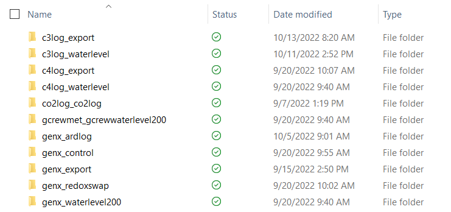

# Join file with metadata

We have two primary metadata documents:

1. “Plot_names” contains the plots, treatments, and overarching experimental design information for the project.

```r
plot_names <- "design documents/gcrew schema drafts/functional/plot_names_SMARTX.csv"
plots <- fread(plot_names)
kable(head(plots)) %>% kable_styling("striped") %>% scroll_box(width = "100%")
```

| site | plot_name | plot_id | treatment_name | transect | warming_level | co2_level | treatment | logger | design_link |
| --- | --- | --- | --- | --- | --- | --- | --- | --- | --- |
| C3 | C3_tr1_T0 | 310 | T0 | tr1 | amb | amb | amb_x_amb | c3log | logger |
| C3 | C3e_tr1_T0 | 610 | eT0 | tr1 | amb | elev | amb_x_elev | c3log | logger |
| C3 | C3_tr1_T1 | 311 | T1 | tr1 | 1.7 | amb | 1.7_x_amb | c3log | logger |
| C3 | C3_tr1_T2 | 312 | T2 | tr1 | 3.4 | amb | 3.4_x_amb | c3log | logger |
| C3 | C3_tr1_T3 | 313 | T3 | tr1 | 5.1 | amb | 5.1_x_amb | c3log | logger |
| C3 | C3e_tr1_T3 | 613 | eT3 | tr1 | 5.1 | elev | 5.1_x_elev | c3log | logger |

2. “Design_role” contains every single variable from LoggerNet and the scale that it is relevant to (e.g., plot, treatment, or experiment-scale).

```r
design_table <- "design documents/gcrew schema drafts/functional/design_role_SMARTX.csv"
design <- fread(design_table)
kable(head(design)) %>% kable_styling("striped") %>% scroll_box(width = "100%")
```

| loggernet_variable | cr1000_name | design_scale_type | design_link | var_norm_split | research_name | logger | type | units | definition | table |
| --- | --- | --- | --- | --- | --- | --- | --- | --- | --- | --- |
| _Wind_Dir_STD | _wind_dir_std | site | logger | n | wind_dir_std | c3log | number | degrees | standard deviation of wind direction | NA |
| _Wind_Dir_STD | _wind_dir_std | site | logger | n | wind_dir_std | c4log | number | degrees | standard deviation of wind direction | NA |
| A_DC(1) | a_dc1 | treatment | T1 | y | a_dc | c3log | number | NA | computed duty cycle proportion aboveground (0-1) | NA |
| A_DC(1) | a_dc1 | treatment | T1 | y | a_dc | c4log | number | NA | computed duty cycle proportion aboveground (0-1) | NA |
| A_DC(2) | a_dc2 | treatment | T2 | y | a_dc | c3log | number | NA | computed duty cycle proportion aboveground (0-1) | NA |
| A_DC(2) | a_dc2 | treatment | T2 | y | a_dc | c4log | number | NA | computed duty cycle proportion aboveground (0-1) | NA |

The code is currently run manually - the user needs to specify the logger and table that they want to process.

The function `new_norm_smartx()` unfolds the LoggerNet columns according to the experimental design and assigns them to the correct plots.

## Function execution

```r
# User defines variables for manual processing
logger <- c("c3log")
table <- c("export")
increment <- 15

# Check that these are the correct files that you want to process
dirs_for_norm <- norm_files(my_dirs$sorted, logger, table)
```

```
## [1] "The directories you want to normalize are as follows:"
## [1] "C:/Users/ChengS1/OneDrive - Smithsonian Institution/Documents/SMARTX_processing_test/2_sorted/sorted_working/c3log_export"
```

```r
# Process files
new_norm_smartx(dirs_for_norm, my_dirs$normal, design_table, plot_names, increment)
```

```
## [1] "Files have been normalized."
```

| site | plot_id | logger | plot_name | treatment_name | transect | warming_level | co2_level | treatment | rowid | time2 | timestamp | record | tref_avg1 | tref_avg2 | tref_avg3 | flag1 | flag2 | flag3 | flag4 | flag5 | flag6 | flag7 | flag8 | flag9 | flag10 | flag11 | flag12 | flag13 | flag14 | … |
| --- | --- | --- | --- | --- | --- | --- | --- | --- | --- | --- | --- | --- | --- | --- | --- | --- | --- | --- | --- | --- | --- | --- | --- | --- | --- | --- | --- | --- | --- | --- |
| c3 | 310 | c3log | c3_tr1_t0 | t0 | tr1 | amb | amb | amb_x_amb | gcrew_2021-03-24 02:00:00_c3log | 2021-03-24 02:00:00 | 2021-03-24 02:00:00 | 61683 | 11.56 | 11.52 | 11.50 | -1 | -1 | -1 | -1 | 0 | 0 | 0 | 0 | -1 | 0 | 0 | 0 | 0 | 0 | … |
| c3 | 310 | c3log | c3_tr1_t0 | t0 | tr1 | amb | amb | amb_x_amb | gcrew_2021-03-24 02:15:00_c3log | 2021-03-24 02:15:00 | 2021-03-24 02:15:00 | 61684 | 11.52 | 11.49 | 11.45 | -1 | -1 | -1 | -1 | 0 | 0 | 0 | 0 | -1 | 0 | 0 | 0 | 0 | 0 | … |
| c3 | 310 | c3log | c3_tr1_t0 | t0 | tr1 | amb | amb | amb_x_amb | gcrew_2021-03-24 02:30:00_c3log | 2021-03-24 02:30:00 | 2021-03-24 02:30:00 | 61685 | 11.47 | 11.43 | 11.38 | -1 | -1 | -1 | -1 | 0 | 0 | 0 | 0 | -1 | 0 | 0 | 0 | 0 | 0 | … |
| c3 | 310 | c3log | c3_tr1_t0 | t0 | tr1 | amb | amb | amb_x_amb | gcrew_2021-03-24 02:45:00_c3log | 2021-03-24 02:45:00 | 2021-03-24 02:45:00 | 61686 | 11.43 | 11.38 | 11.34 | -1 | -1 | -1 | -1 | 0 | 0 | 0 | 0 | -1 | 0 | 0 | 0 | 0 | 0 | … |
| c3 | 310 | c3log | c3_tr1_t0 | t0 | tr1 | amb | amb | amb_x_amb | gcrew_2021-03-24 03:00:00_c3log | 2021-03-24 03:00:00 | 2021-03-24 03:00:00 | 61687 | 11.41 | 11.36 | 11.32 | -1 | -1 | -1 | -1 | 0 | 0 | 0 | 0 | -1 | 0 | 0 | 0 | 0 | 0 | … |
| c3 | 310 | c3log | c3_tr1_t0 | t0 | tr1 | amb | amb | amb_x_amb | gcrew_2021-03-24 03:15:00_c3log | 2021-03-24 03:15:00 | 2021-03-24 03:15:00 | 61688 | 11.39 | 11.36 | 11.32 | -1 | -1 | -1 | -1 | 0 | 0 | 0 | 0 | -1 | 0 | 0 | 0 | 0 | 0 | … |
| c3 | 310 | c3log | c3_tr1_t0 | t0 | tr1 | amb | amb | amb_x_amb | gcrew_2021-03-24 03:30:00_c3log | 2021-03-24 03:30:00 | 2021-03-24 03:30:00 | 61689 | 11.39 | 11.36 | 11.32 | -1 | -1 | -1 | -1 | 0 | 0 | 0 | 0 | -1 | 0 | 0 | 0 | 0 | 0 | … |
| c3 | 310 | c3log | c3_tr1_t0 | t0 | tr1 | amb | amb | amb_x_amb | gcrew_2021-03-24 03:45:00_c3log | 2021-03-24 03:45:00 | 2021-03-24 03:45:00 | 61690 | 11.41 | 11.36 | 11.33 | -1 | -1 | -1 | -1 | 0 | 0 | 0 | 0 | -1 | 0 | 0 | 0 | 0 | 0 | … |
| c3 | 310 | c3log | c3_tr1_t0 | t0 | tr1 | amb | amb | amb_x_amb | gcrew_2021-03-24 04:00:00_c3log | 2021-03-24 04:00:00 | 2021-03-24 04:00:00 | 61691 | 11.42 | 11.37 | 11.34 | -1 | -1 | -1 | -1 | 0 | 0 | 0 | 0 | -1 | 0 | 0 | 0 | 0 | 0 | … |
| c3 | 310 | c3log | c3_tr1_t0 | t0 | tr1 | amb | amb | amb_x_amb | gcrew_2021-03-24 04:15:00_c3log | 2021-03-24 04:15:00 | 2021-03-24 04:15:00 | 61692 | 11.44 | 11.39 | 11.36 | -1 | -1 | -1 | -1 | 0 | 0 | 0 | 0 | -1 | 0 | 0 | 0 | 0 | 0 | … |

## Function code

```r
new_norm_smartx <- function(source_dir, norm_dir, design_table, plot_names, increment){
  norm_working <- paste0(norm_dir, "/normal_working")

  # Read in experimental design tables
  design <- fread(design_table)
  plotname <- fread(plot_names)

  # Set key for plotname and design tables to speed joining
  merge_key = c("logger","design_link")
  setkeyv(plotname, merge_key)
  setkeyv(design, merge_key)

  # Prepare plotname and design tables for merging (set everything to lowercase and class data.table)
  plotname <- lapply(plotname, tolower)
  plotname <- as.data.table(plotname)

  design <- lapply(design, tolower)
  design <- as.data.table(design)

  # Merge plotname and design to create big table that includes all of the measurements / parameters that apply to each plot
  design <- merge(plotname, design, allow.cartesian = TRUE, by = merge_key)

  # Identify variable types "key", "site", and "plot" level from "var_norm_split" variable in design document
  temp <- design[var_norm_split == "key",]
  key <- unique(as.vector(temp$cr1000_name))

  temp <- design[var_norm_split == "n",]
  site <- unique(as.vector(temp$cr1000_name))

  temp <- design[var_norm_split == "y",]
  plot <- unique(as.vector(temp$cr1000_name))

  # List file paths from source directory. i includes full file path
  i <- list.files(source_dir, pattern = NULL, all.files = FALSE,
                  full.names = TRUE, recursive = TRUE,
                  ignore.case = FALSE)

  # If there are no files to read in the specified directory,
  # tell the user and stop the function from running so it doesn't break down the line.
  if(length(i) == 0){
    stop("No files to normalize in the specified directories.")
  }

  for(n in 1:length(i)){
    # This will go within a for loop in the function
    dt <- fread(i[n])

    # Edit column names for ease of use
    setnames(dt, tolower(names(dt)))
    newnames <- names(dt)
    newnames <- gsub("[(]", "", newnames)
    newnames <- gsub("[)]", "", newnames)
    setnames(dt, newnames)

    # Make all data lowercase
    # dt <- lapply(dt, function(x) {gsub("NaN", NA, x)})
    dt <- lapply(dt, tolower)
    dt <- as.data.table(dt)

    # Deal with cases where logger might be NA -- set to statname1. Old code
    # dt[, logger := ifelse(is.na(dt$logger) == TRUE, statname1, logger)]

    ## Format time so that minute is rounded to the nearest X-minute increment
    Sys.setenv(TZ = "America/Cancun") ### set for EST all year long
    dt <- subset(dt, grepl("20..-..-.. ..:..:..", dt$timestamp))
    dt$timestamp <- as.POSIXct(dt$timestamp)

    # Create new time variable
    minute_time <- round(minute(dt$timestamp)/increment)*increment
    dt$time2 <- update(dt$timestamp, min = minute_time)

    # Create row id
    dt$rowid <- paste("gcrew", dt$timestamp, dt$logger, sep="_")

    # Separate data into plot level and site level by selecting relevant variables
    plot_name <- c(key, plot)
    site_name <- c(key, site)

    dt_site <- subset(dt, select = names(dt) %in% site_name) # site data for merge
    dt_plot <- subset(dt, select = names(dt) %in% plot_name) # plot level to denormalize

    ### Normalize data
    # Stack block/site data (long form data)
    site_key <- c("logger", "rowid", "time2", "timestamp")
    dt_site2 <- melt(dt_site, id.vars = site_key, measure.vars = , variable.name = "cr1000_name", na.rm = FALSE)
    dt_site2 <- unique(dt_site2)

    # Stack plot data
    plot_key <- c("logger", "rowid", "time2")
    dt_plot2 <- melt(dt_plot, id.vars = plot_key, measure.vars = , variable.name = "cr1000_name", na.rm = FALSE)

    # If there are no plot variables, join just the site data to the design data
    if(("cr1000_name" %in% colnames(dt_plot2)) == F){
      # Merge site level data and design attributes (really just the site name and the type of data)
      merge_key = c("logger", "cr1000_name")
      setkeyv(dt_site2, merge_key)
      setkeyv(design, merge_key)
      dt_site_merged <- merge(dt_site2, design, allow.cartesian = TRUE, by = merge_key)
      # Select only the relevant columns
      dt_site_merged <- subset(dt_site_merged, select = c("site", "logger", "rowid", "time2", "timestamp",
                                                          "value", "research_name", "cr1000_name", "type"))

      ## Collect only numeric data, remove duplicate rows, and set to numeric class
      dt_site_merged_num <- dt_site_merged[type == "number", ]
      setkey(dt_site_merged_num, NULL)
      dt_site_merged_num <- unique(dt_site_merged_num)
      dt_site_merged_num$value <- as.double(dt_site_merged_num$value)

      # Recast site level data to wide format with each variable as its own column (wide)
      dt_site_wide <- dcast(dt_site_merged_num, site+logger+rowid+time2+timestamp ~ cr1000_name,
                            subset = NULL, drop = TRUE, value.var = "value") # note that fill should be allowed to default

      # Normalized dt for output
      dt_normalized <- dt_site_wide
    } else{ # Otherwise, merge plot and site level data
      # Merge plot level values and timestamps with design table
      merge_key = c("logger", "cr1000_name")
      setkeyv(dt_plot2, merge_key)
      setkeyv(design, merge_key)
      dt_plot3 <- merge(dt_plot2, design, allow.cartesian = TRUE, by = merge_key)

      # Select only the variables we want.
      dt_plot4 <- subset(dt_plot3, select = c("rowid", "time2", "logger", "plot_id", "value", "research_name", "cr1000_name", "type"))

      ## Collect only numeric data, remove duplicate rows, and set to numeric class
      dt_plot4_num <- dt_plot4[type == "number", ]

      setkey(dt_plot4_num, NULL)
      dt_plot4_num <- unique(dt_plot4_num)
      dt_plot4_num$value <- as.double(dt_plot4_num$value)

      # Recast data to wide format with each variable as its own column
      dt_plot_wide <- dcast(dt_plot4_num, plot_id+rowid+logger+time2 ~ research_name, fun.aggregate = mean_rm,
                            subset = NULL, drop = TRUE, value.var = "value") # note that fill should be allowed to default

      # Recast site level data to wide format with each variable as its own column
      dt_site_wide <- dcast(dt_site2, rowid+logger+time2+timestamp ~ cr1000_name,
                            subset = NULL, drop = TRUE, value.var = "value") # note that fill should be allowed to default

      # Merge non normalized variables with data
      key2 <-c("rowid","logger","time2")
      setkeyv(dt_plot_wide, key2)
      setkeyv(dt_site_wide, key2)

      dt_merged <- merge(dt_site_wide, dt_plot_wide, allow.cartesian = TRUE, by = key2)

      # Get plotnames again and merge plot attributes with dt_merged
      # plotname2 <- as.data.table(unique(subset(plotname, select= c("site", "plot_id","logger", "plot_name",
      #                                                              "treatment_name", "transect","warming_level","co2_level","treatment"))))
      plotname2 <- as.data.table(unique(subset(plotname, select = -design_link)))

      key2 <- c("plot_id", "logger")
      setkeyv(dt_merged, key2)
      setkeyv(plotname2, key2)
      dt_merged <- plotname2[dt_merged]

      # Set final data for output
      dt_normalized <- dt_merged
    }

    # Get table name from i
    table_name <- unlist(strsplit(i[n], "/"))
    table_name <- table_name[length(table_name)]

    ### Save table to directory
    path <- paste("norm_", table_name, sep = "")
    out_path <- paste(norm_working, path, sep = "/")

    # Save table to norm_working
    write.table(dt_normalized, out_path, append = FALSE, quote = FALSE, sep = ",",
                na = "NA", dec = ".", row.names = FALSE,
                col.names = TRUE, qmethod = c("escape", "double"))

    # Copy original file to sorted_archive
    sort_dir <- unlist(strsplit(i[n], "/sorted_working/"))
    folder <- unlist(strsplit(sort_dir[2], "/"))[1]
    copy_dir <- paste0(sort_dir[1], "/sorted_archive/", folder)

    file.copy(i[n], copy_dir)
    # Remove original file from sorted_working
    file.remove(i[n])
  }
  print("Files have been normalized.")
}
```

# Monthly (and yearly) aggregation

The last step for packaging the data is to aggregate it by month and year. The data will then be made available to researchers by project, month, and year.

We sort the final data using the “logger_role” document, which matches every LoggerNet table with the appropriate project (e.g., GENX, SMARTX, GCREW Marsh Outlet, etc.)

```r
logger_role <- "design documents/logger_x_project.csv"
logger_project <- fread(logger_role)
kable(logger_project) %>% kable_styling("striped") %>% scroll_box(width = "100%")
```

| pattern | project |
| --- | --- |
| c3log | gcrew_smartx |
| c4log | gcrew_smartx |
| co2log | gcrew_smartx |
| gcrewmarshoutlet | gcrew_outlet |
| gcrewmet | gcrew_met |
| genx | gcrew_genx |
| genxlgr | gcrew_genx |
| genxorganb | gcrew_genx_organ |
| genxorganf | gcrew_genx_organ |
| redox1 | gcrew_smartx_redox |
| redox2 | gcrew_smartx_redox |
| redox3 | gcrew_smartx_redox |
| waterlevel | gcrew_waterlevel |

The `monthlymanage()` function aggregates data for a certain logger and table by month. If the data has already been aggregated by month but you need to tack more days on, the function will also do so.

## Function execution

```r
# Define the table you want to aggregate and get the corresponding filepaths
table <- c("export")
dirs_for_month <- monthly_files(my_dirs$normal, table)
```

```
## [1] "The files you want to aggregate by month are as follows:"
## [1] "C:/Users/ChengS1/OneDrive - Smithsonian Institution/Documents/SMARTX_processing_test/3_normal/normal_working/norm_export_2021-03-10_01-45-00_c3log_1344_TOA5_.csv"
## [2] "C:/Users/ChengS1/OneDrive - Smithsonian Institution/Documents/SMARTX_processing_test/3_normal/normal_working/norm_export_2021-03-24_01-45-00_c3log_1343_TOA5_.csv"
## [3] "C:/Users/ChengS1/OneDrive - Smithsonian Institution/Documents/SMARTX_processing_test/3_normal/normal_working/norm_export_2021-04-07_01-45-00_c3log_1344_TOA5_.csv"
```

```r
# Aggregate by month
monthlymanage(dirs_for_month, my_dirs$monthly, out_path, logger_role)
```

## Function code

```r
monthlymanage <- function(source_files, monthly_dir, out_path, logger_role){
  norm_working <- paste0(unlist(strsplit(source_files[1], "/normal_working/"))[1], "/normal_working")
  norm_archive <- paste0(unlist(strsplit(source_files[1], "/normal_working/"))[1], "/normal_archive")
  logger_role <- read.csv(logger_role)

  if(length(source_files) == 0){
    stop("There are no files to aggregate that match your specified table and year")
  }

  for (n in 1:length(source_files)){
    # Read in data table
    dt <- fread(source_files[n])

    # Format time
    dt$time2 <- as.POSIXct(dt$time2)

    # Create year, month, and logger variables to create a key data frame
    # Create a different table for every combination of month, year, and logger
    dates <- unique(format(dt$time2, "%Y-%m"))
    dates <- strsplit(dates, "-")
    logger <- unique(tolower(dt$logger))
    y2 <- data.frame(yr = as.integer(sapply(dates, "[[", 1)),
                     mo = as.integer(sapply(dates, "[[", 2)),
                     logger = logger, row.names = NULL)

    # Find output directory
    table <- gsub("_", "", unique(tolower(dt$table)))
    logger <- gsub("_", "", unique(tolower(dt$logger)))
    if(grepl("waterlevel", table, ignore.case = TRUE) == TRUE){
      folder <- "gcrew_waterlevel"
    } else{
      folder <- logger_role$project[which(logger_role$pattern == logger)]
    }

    output_dir <- paste0(out_path, "/", folder, "/monthly")
    if(!dir.exists(output_dir)) dir.create(output_dir)

    for (m in 1:nrow(y2)) {
      # Subset data by month and save each one as a different file
      dtplot <- subset(dt, month(dt$time2) == y2$mo[m] & dt$logger == y2$logger[m] & year(dt$time2) == y2$yr[m])
      path <- paste(gsub("_", "", y2$logger[m]), table, y2$mo[m], y2$yr[m], sep = "_")
      path <- paste(path, "csv", sep = ".")
      path_out <- paste(output_dir, path, sep = "/")
      path_monthly <- paste(monthly_dir, path, sep = "/")

      # If there's already a data table with the same name, bind rows together and overwrite
      if (file.exists(path_out) == TRUE) {
        dt2 <- fread(path_out)
        dt2 <- rbind.fill(dtplot, dt2)
        dt2 <- unique(dt2)
        dt2 <- as.data.table(dt2)

        write.table(dt2, path_out, append = FALSE, quote = FALSE, sep = ",",
                    na = "NA", dec = ".", row.names = FALSE,
                    col.names = TRUE, qmethod = c("escape", "double"))
        write.table(dt2, path_monthly, append = FALSE, quote = FALSE, sep = ",",
                    na = "NA", dec = ".", row.names = FALSE,
                    col.names = TRUE, qmethod = c("escape", "double"))

        # Otherwise, if the data table doesn't exist yet, just save it to the output dir
      } else if (file.exists(path_out) == FALSE) {
        write.table(dtplot, path_out, append = FALSE, quote = FALSE, sep = ",",
                    na = "NA", dec = ".", row.names = FALSE,
                    col.names = TRUE, qmethod = c("escape", "double"))
        write.table(dtplot, path_monthly, append = FALSE, quote = FALSE, sep = ",",
                    na = "NA", dec = ".", row.names = FALSE,
                    col.names = TRUE, qmethod = c("escape", "double"))
      }
    }

    # Copy file to norm_archive
    file.copy(source_files[n], norm_archive)
    # Remove file from norm_working
    file.remove(source_files[n])
  }
}
```